# Compare classifications with HPA

Tom Smith

Cambridge Centre for Proteomics

Lisa Breckels

Cambridge Centre for Proteomics

13 September, 2023

Abstract

Here, we compare the protein subcellular localisation classification with HPA.

First let’s load the packages we need for the analysis -

```r
library(MSnbase)
library(pRolocdata)
library(dplyr)
library(tidyr)
library(camprotR)
library(ggplot2)
library(mcclust)
```

- Read in all LOPIT datasets. These are the protein level dLOPIT dataset and two previously published datasets from Geladaki et al 2018 which are available in `pRolocdata` from using the hyperLOPIT and LOPIT-DC technologies
- We also read in data from the Human Protein Atlas (HPA) downloaded from https://www.proteinatlas.org/about/download on 3rd May 2023.
- In the following code chunks we re-code the names of the markers in each dataset to a common format compatible with both LOPIT and HPA annotations.

```r
## ----------------------------------------------------------------------------
## -----------------------Read in dLOPIT --------------------------------------
## ----------------------------------------------------------------------------

## read the dLOPIT data
dlopit <- readRDS('../../out/combined_protein_res_inc_bandle_loc.rds')$DMSO

## select columns with results
dl <- fData(dlopit)[, c("markers","bandle_alloc"), drop = FALSE]
mrk <- dl$markers[dl$markers != "unknown"]

## add the markers to the allocation results (to match notation in all pRolocdata sets, we filter these further down)
dl$bandle_alloc[is.na(dl$bandle_alloc)] <- mrk

## recode the organelle names to match the HPA terms
dl$classification <- recode(dl$bandle_alloc,
                                    'NUCLEOPLASM-1'='NUCLEUS',
                                    'NUCLEOPLASM-2'='NUCLEUS',
                                    'PROTEIN COMPLEX'='CYTOSOL',
                                    'RIBOSOME'='CYTOSOL',
                                    'MITOCHONDRION'='MITOCHONDRIA')
## remove any proteins which are classes as "Undefined" as these can't be compared to the HPA
dl <- filter(dl, classification != "Undefined")
dl %>% head

## ----------------------------------------------------------------------------
## ---------------------Read in hyperLOPIT data--------------------------------
## ----------------------------------------------------------------------------

## read in the hyperLOPIT U2OS data from pRolocdata
data("hyperLOPITU2OS2018")
hl <- fData(hyperLOPITU2OS2018)[, c("markers", "final.assignment"), drop = FALSE]
hl$classification <- recode(hl$final.assignment,
                                    'GA'='GOLGI',
                                    'CHROMATIN'='NUCLEUS',
                                    'RIBOSOME 40S'='CYTOSOL',
                                    'RIBOSOME 60S'='CYTOSOL',
                                    'PROTEASOME'='CYTOSOL',
                                    'MITOCHONDRION'='MITOCHONDRIA')
hl <- filter(hl, classification != "unknown")
hl %>% head

## ----------------------------------------------------------------------------
## ---------------------Read in LOPIT-DC data ---------------------------------
## ----------------------------------------------------------------------------

## read in the lopit-DC U2OS data from pRolocdata
data("lopitdcU2OS2018")
dc <- fData(lopitdcU2OS2018)[, c("markers", "final.assignment"), drop = FALSE]
dc$classification <- recode(dc$final.assignment,
                                    'GA'='GOLGI',
                                    'NUCLEUS/CHROMATIN'='NUCLEUS',
                                    'RIBOSOME'='CYTOSOL',
                                    'PROTEASOME'='CYTOSOL',
                                    'MITOCHONDRION'='MITOCHONDRIA')
dc <- filter(dc, classification != "unknown")
dc %>% head
```

In the next code chunk we re-code HPA annotations to the same naming scheme as LOPIT.

```r
## ----------------------------------------------------------------------------
## ---------------------Read in HPA data --------------------------------------
## ----------------------------------------------------------------------------

## get HPA locations and make the same annotation labels as what we have in our data
locs <- c("CYTOSOL", "ER", "GOLGI", "LYSOSOME", "MITOCHONDRIA",
          "NUCLEUS", "PEROXISOME", "PM")
hpa <- readRDS('../../../../1_external/19_hpa/out/hpa_allocations.rds')
hpa <- hpa %>%
  mutate(allocation_LOPIT_classes=recode(
    allocation,
    'Cytoplasmic bodies'='CYTOSOL',
    "Cytosol"="CYTOSOL",
    "Endoplasmic reticulum"="ER",
    "Golgi apparatus"="GOLGI",
    "Lysosomes"="LYSOSOME",
    "Mitochondria"="MITOCHONDRIA",
    "Nuclear bodies"="NUCLEUS",
    "Nuclear membrane"="NUCLEUS",
    "Nuclear speckles"="NUCLEUS",
    "Nucleoli fibrillar center"="NUCLEUS",
    "Nucleoli"="NUCLEUS",
    "Nucleoplasm"="NUCLEUS",
    "Nucleus"="NUCLEUS",
    "Peroxisomes"="PEROXISOME",
    "Plasma membrane"="PM")) %>%
  filter(allocation_LOPIT_classes %in% locs) %>%
  filter(hpa_confidence != "Uncertain") %>%
  mutate(hpa_confidence = factor(hpa_confidence, levels = c("Enhanced", "Supported", "Approved"))) %>%
  arrange(factor(hpa_confidence, levels = c("Enhanced", "Supported", "Approved"))) %>%
  mutate(hpa_confidence = as.character(hpa_confidence))
table(hpa$allocation_LOPIT_classes)
table(hpa$hpa_confidence)
hpa %>% head
hpa %>% tail
```

We next define a function to find if the HPA image annotation matches each dataset

```r
## ----------------------------------------------------------------------------
## comparePredictions
## ----------------------------------------------------------------------------
## This function compares a data.frame of classification results
## from LOPIT/BANDLE classification against the HPA annotation.
##    df:  data.frame of results (accession numbers as rownames), classification in column
##    col: name of the column containing the classification results to compare to the HPA
##    na.rm: logical defining if we should remove proteins with no annotation available
##           in the HPA. Default is TRUE.
## ----------------------------------------------------------------------------
comparePredictions <- function(df,
                               col = "classification",
                               na.rm = TRUE) {
  ## init
  hpa_class <- vector("character")
  hpa_level <- vector()
  res_tf <- vector("logical")

  ## get vector of predictions for LOPIT data
  ids <- rownames(df)
  preds <- df[, col]
  names(preds) <- ids

  ## see if we have a match with the HPA image data
  for (i in seq_along(ids)) {
  res <- hpa %>%
    filter(uniprotswissprot == ids[i]) %>%
    select(hpa_confidence, allocation_LOPIT_classes)
  # tmp[[i]] <- res
  if (nrow(res) > 0) {   # if the image data is available check if it agrees
    .res <- res$allocation_LOPIT_classes
    .lev <- res$hpa_confidence
    res_tf[i] <- preds[i] %in% .res
    if (res_tf[i]) {      # terms agree
      ind <- match(preds[i], .res)
      hpa_class[i] <- .res[ind]
      hpa_level[i] <- .lev[ind]
    } else {              # terms do not agree
      set.seed(1)
      hpa_class[i] <- sample(.res, size = 1)
      hpa_level[i] <- sample(.lev, size = 1)
    }
  } else {
    hpa_class[i] <- NA
    res_tf[i] <- NA
    hpa_level[i] <- NA
    }
  }
  ## create a data.frame of results
  df_res <- data.frame(mrk = df$markers,
                       lev = hpa_level,
                       hpa = hpa_class,
                       dl = preds,
                       tf = res_tf,
                       row.names = ids)
  if (na.rm) df_res <- df_res[!is.na(df_res$tf), ]
  return(df_res)
}
```

- We now run the `comparePredictions` function on each dataset
- The LOPIT results are stored in `data.frames` and put into a `list` for ease of coding
- We then tabulate the output
- For each dataset we have an output `data.frame` displaying the protein accessions numbers. `mrk` = denotes if the protein is a marker protein, `lev` denotes the HPA evidence level, `hpa`= the annotation recorded by the HPA at the given evidence level, `dl` = the annotation from LOPIT, `tf` = logical, does the annotation agree between LOPIT and the HPA.

```r
## put LOPIT results into a list
lopits <- list(dl, hl, dc)
names(lopits) <- c("dLOPIT", "hyperLOPIT", "LOPIT-DC")

## apply the "comparePredictions" function to see our results match the HPA
res <- lapply(lopits, comparePredictions)
names(res) <- names(lopits)

## Output results are a list, where each index refers to the LOPIT expt.
res[[1]] %>% head
res[[2]] %>% head
res[[3]] %>% head
```

- Make a note of the number of proteins we have in our data for which we have evidence from the HPA

```r
(num_prots <- lapply(res, nrow))
```

- Calculate concordance.
- In the next code chunk we define a function `getAgreement` to calculate the agreement (concordance) between our LOPIT data and the HPA data.

```r
## ----------------------------------------------------------------------------
## getAgreement
## ----------------------------------------------------------------------------
## Get agreement between HPA data levels and LOPIT models
##    df: data.frame of LOPIT results
##    support: HPA evidence level
##    concordance: logical. Default is TRUE. If FALSE number of TRUE is reported.
## ----------------------------------------------------------------------------
getAgreement <- function(df,
                         support = c("Approved", "Enhanced", "Supported"),
                         concordance = TRUE
                         ) {
  df <- df %>% filter(lev %in% support)
  res1_true <- table(df[, "tf"])[2]
  res2_true <- table(df[df$mrk == "unknown", "tf"])[2]
  res3_true <- table(df[df$mrk != "unknown", "tf"])[2]
  res1 <- res1_true/nrow(df)
  res2 <- res2_true/nrow(df[df$mrk == "unknown", ])
  res3 <- res3_true/nrow(df[df$mrk != "unknown", ])
  if (concordance)
    res <- c(res1, res2, res3)
  else
    res <- c(res1_true, res2_true, res3_true)
  names(res) <- c("all", "only_predictions", "only_markers")
  return(res)
}
```

- Calculate the agreement for each confidence level available in the HPA

```r
## All levels
all_levs <- lapply(res, getAgreement)
## Enhanced only
enhanced_levs <- lapply(res, getAgreement, support = "Enhanced")
## Approved only
supported_levs <- lapply(res, getAgreement, support = "Supported")
## Approved only
approved_levs <- lapply(res, getAgreement, support = "Approved")

## Tabulate results
concord_tbls <- lapply(seq_along(lopits), function(x)
  cbind(all = all_levs[[x]],
        Enhanced = enhanced_levs[[x]],
        Supported = supported_levs[[x]],
        Approved = approved_levs[[x]]))
names(concord_tbls) <- names(lopits)

concord_tbls
```

First let’s plot our results so far -

```r
par(mfrow = c(1, 3))
barplot(concord_tbls$dLOPIT[1, ]*100,
        ylab = "Agreement with the HPA (%)",
        ylim = c(0, 100),
        main = "dLOPIT (all proteins)",
        xlab = "HPA evidence level")

barplot(concord_tbls$dLOPIT[2, ]*100,
        ylab = "Agreement with the HPA (%)",
        ylim = c(0, 100),
        main = "dLOPIT (only predictions)",
        xlab = "HPA evidence level")

barplot(concord_tbls$dLOPIT[3, ]*100,
        ylab = "Agreement with the HPA (%)",
        ylim = c(0, 100),
        main = "dLOPIT (only markers)",
        xlab = "HPA evidence level")
```

[output not shown]

- In the next code chunk we define a funtion to create a null distribution for each LOPIT dataset on which to compare to give some context to the observed agreement.
- The null generates randomly distributed proteins across compartments with the number of proteins in each compartment corresponding to the observed number in each experiment.
- A null is created for each evidence level, and the adjusted rand index, agreement and number of correctly predicted proteins over 1000 samples is calculated.

```r
## ----------------------------------------------------------------------------
## generateNull
## ----------------------------------------------------------------------------
## Generates randomly distributed proteins across compartments with
## the number of proteins in each compartment corresponding to the observed number
## in each experiment.
##    dat:  data.frame of results generated from getAgreement function
##    iter: sample size
##    col:  name of column containing the LOPIT results
## ----------------------------------------------------------------------------
generateNull <- function(dat, iter = 1000, col = "dl") {
  # initilize
  n <- nrow(dat)
  mrk_tbl <- table(dat[, col]) # LOPIT results are found in column called "dl"
  (prop_terms <- mrk_tbl/n)
  (terms <- names(mrk_tbl))
  out_ari <- out_null <- vector()
  out_true <- logical()

  ## set up sampling
  for (i in 1:iter) {
    set.seed(i)
    x <- sample(terms, n, replace=TRUE, prob = prop_terms) # generate random classification
    df_y <- data.frame(markers = dat$mrk, classification = x)
    rownames(df_y) <- rownames(dat)
    res_y <- comparePredictions(df = df_y)
    y <- res_y$hpa
    out_ari[i] <- arandi(x, y)
    out_null[i] <- table(x == y)[2]/n
    out_true[i] <- table(x == y)[2]
  }
  df <- data.frame(ari = out_ari,
                   null = out_null,
                   tf = out_true)
  rownames(df) <- paste0("iteration", 1:iter)
  return(df)
}

## ----------------------------------------------------------------------------
## getNullStats
## ----------------------------------------------------------------------------
## Collates reuslts of generateNull into a data.frame to
## be passed to ggplot for visualisation
##    data:  data.frame of results generated from getAgreement function
##    n:     sample size
## ----------------------------------------------------------------------------
getNullStats <- function(data, n = 1000) {

  ## Initialize objects
  null_stats <- vector("list", 4)
  lev_ind <- c("Enhanced", "Supported", "Approved")

  ## only evaluate predictions, don't include markers
  dat <- data %>% filter(mrk == "unknown")
  null_stats[[1]] <- generateNull(dat, iter = n)
  null_stats[[1]]$n <- nrow(dat)
  for (j in seq_along(lev_ind)) {
    null_dat <- dat %>% filter(lev == lev_ind[j])
    null_stats[[j + 1]] <- generateNull(null_dat, iter = n)
    null_stats[[j + 1]]$n <- nrow(null_dat)
  }
  names(null_stats) <- c("all", lev_ind)
  col_means <- lapply(null_stats, colMeans)
  col_sd <- lapply(null_stats, function(z) apply(z, 2, sd))
  null_df <- do.call(data.frame, col_means) %>% `colnames<-`(c("all", lev_ind))
  null_sd <- do.call(data.frame, col_sd) %>% `colnames<-`(c("all", lev_ind))

  ## structure the results
  null_long <- null_df %>% tibble::rownames_to_column("metric")
  sd_long <- null_sd %>% tibble::rownames_to_column("metric")
  null_long <- gather(null_long, hpa, mean, all:Approved)
  sd_long <- gather(sd_long, hpa, sd, all:Approved)
  null_long <- cbind(null_long, proteins = "only_predictions")
  sd_long <- cbind(sd_long, proteins = "only_predictions")
  null_long <- cbind(null_long, sd = sd_long$sd)
  return(list(summary = null_long,
              raw = null_stats))
}
```

Let’s now generate the models for all datasets by `lapply`ing over the list of datasets.

```r
get_models <- lapply(res, getNullStats)      # this takes approx 1hr to run on 16 core machine
# save(get_models, file = "../../out/hpa_null_models.rda")  # save the data
# load("get_models.rda", verbose = TRUE)     # load saved data
```

Now we have our models, let’s re-structure the results so we can plot using `ggplot2`.

```r
## Load null models
load("../../out/hpa_null_models.rda", verbose = TRUE)

## Extract summary data
null_summaries <- lapply(get_models, "[[", 1)

## Extract raw null data
null_raw <- lapply(get_models, "[[", 2)

## Reshape data for ggplot
rb <- vector("list", length(null_raw))
for (j in seq_along(null_raw)) {
  for (i in seq_along(null_raw[[j]])) {
  null_raw[[j]][[i]][, "method"] <- names(null_raw)[j]
  null_raw[[j]][[i]][, "hpa"] <- names(null_raw[[j]])[i]
  }
  rb[[j]] <- do.call(rbind, null_raw[[j]])
}
null_dat <- do.call(rbind, rb)
```

- Calculate the true ARI for all HPA evidence levels and sets of proteins

```r
## ----------------------------------------------------------------------------
## getARI
## ----------------------------------------------------------------------------
## Takes a data.frame of classification results as input and compares them with
## the HPA by computing the ARI.
## ----------------------------------------------------------------------------
getARI <- function(df, support = c("Approved", "Enhanced", "Supported")) {
  lev <- c("Approved", "Enhanced", "Supported")
  df <- df %>% filter(lev %in% support)
  res1 <- df$dl
  res2 <- df$hpa
  ## calcualte ari for all proteins
  true_ari1 <- arandi(res1, res2)
  ## caluclate for only predictions (no markers)
  ind <- which(df$mrk == "unknown")
  true_ari2 <- arandi(res1[ind], res2[ind])
  ## calcualate for only markers (for comparison)
  ind <- which(df$mrk != "unknown")
  true_ari3 <- arandi(res1[ind], res2[ind])
  res <- c(true_ari1, true_ari2, true_ari3)
  names(res) <- c("all", "only_predictions", "only_markers")
  return(res)
}
```

Calculate the ARI

```r
## All level
all_levs_ari <- getARI(res$dLOPIT)
## Enhanced only
enhanced_levs_ari <- getARI(res$dLOPIT, support = "Enhanced")
## Supported only
supported_levs_ari <- getARI(res$dLOPIT, support = "Supported")
## Approved only
approved_levs_ari <- getARI(res$dLOPIT, support = "Approved")
## results as a df
df_ari <- cbind(all = all_levs_ari,
                enhanced = enhanced_levs_ari,
                supported = supported_levs_ari,
                approved = approved_levs_ari)
```

- The `getResults` function arranges and collates all our results for `ggplot2`

```r
## ----------------------------------------------------------------------------
## getResults: collate data for ggplot
## ----------------------------------------------------------------------------
getResults <- function(res, nulls) {
  ## wrangle data into table for plotting
  df_x <- vector("list", length(res))
  for (i in seq_along(res)) {
    df <- data.frame(concord_tbls[[i]]) %>% tibble::rownames_to_column("proteins")
    (df <- gather(df, hpa, concordance, all:Approved))
    df <- df %>% arrange(proteins, hpa)
    ## get number of proteins in for each HPA level
    x_all <- res[[i]] %>%
      group_by(lev) %>%
      count()
    x_all <- c(x_all$n, sum(x_all$n))
    x_mrk <- res[[i]] %>%
      group_by(lev, unknowns = (mrk == "unknown")) %>%
      count() %>%
      filter(unknowns == FALSE)
    x_mrk <- c(x_mrk$n, sum(x_mrk$n))
    x_pred <- res[[i]] %>%
      group_by(lev, unknowns = (mrk == "unknown")) %>% count() %>%
      filter(unknowns == TRUE)
    x_pred <- c(x_pred$n, sum(x_pred$n))
    df_x[[i]] <- cbind(lopit = names(res)[i], df, n = c(x_all, x_mrk, x_pred))
  }
  df <- do.call(rbind, df_x)
  df$hpa <- factor(df$hpa, levels = c("all", c("Enhanced", "Supported", "Approved")))
  df <- df %>% filter(proteins == "only_predictions")
  df$sd <- NA
  df <- df[, c(1:4, 6, 5)]
  ## now add null model data
  for (i in seq_along(nulls)) {
    x_null <- nulls[[i]] %>% filter(metric == "null")
    null_n <- nulls[[i]] %>% filter(metric == "n") %>% select(n = mean)
    x_null <- cbind(x_null[, c("metric", "proteins", "hpa", "mean", "sd")], null_n)
    names(x_null) <- c("lopit", "proteins", "hpa", "concordance", "sd", "n")
    x_null[, "lopit"] <- paste0("null_", names(res)[i])
    df <- rbind(df, x_null)
  }
  names(df)[4] <- "Mean"
  df <- df %>% select(-proteins)
  ind <- c(grep("dLOP", df$lopit),
           grep("hyper", df$lopit),
           grep("DC", df$lopit))
  df <- df[ind, ]
  df$lopit <- factor(df$lopit,
                     levels = c("null_dLOPIT", "dLOPIT", "null_hyperLOPIT",
                                "hyperLOPIT", "null_LOPIT-DC", "LOPIT-DC"))
  df$values <- rep(rep(c("observed", "null"), each = 4), 3)
  df$method <- rep(c("dLOPIT", "hyperLOPIT", "LOPIT-DC"), each = 8)
  return(df)
}
```

Get plotting data

```r
(plot_data <- getResults(res, null_summaries))
```

Barplot for HPA agreement with every HPA level of evidence defined explicitly

```r
p <- plot_data %>%
  filter(hpa != "all") %>%
    ggplot(aes(x = values, y =100*Mean, fill = method)) +
    geom_bar(stat='identity') +
    # geom_errorbar(aes(ymin = (Mean*100)-sd, ymax = (Mean*100) + sd),
                  # width = .25, position = position_dodge(.9), colour='grey40') +
    facet_grid(hpa~method) +
    theme_camprot(border = FALSE, base_family = 'sans', base_size = 15) +
    theme(strip.background = element_blank(), axis.text.x = element_text(angle = 45, vjust = 1, hjust = 1)) +
    xlab('') +
    ylab('Agreement with HPA (%)') +
    ylim(0, 100*(max(plot_data$Mean)*1.05)) +
    geom_text(aes(y = 10, label = n), colour = 'white') +
    # geom_text(aes(y = 100*Mean/2, label = n), colour = 'grey20')
    geom_text(aes(label = sprintf('%1.f', 100*Mean)), vjust = -0.2, colour = 'grey20') +
    # scale_fill_manual(values = c("#7E5D8CFF", "#47A7A3FF", "#FFEC62FF")) +
    scale_fill_manual(values = c("#5D5D5D", "#9B9B9B", "#D9D9D9")) +
    theme(legend.position = "none")

p
ggsave("../../../../5_manuscript_figures/Figure_1/hpa/barplot_all_levels.png",
       height=8, width=8)
```

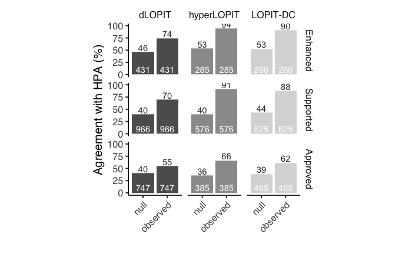

```r
ggsave("../../../../5_manuscript_figures/Figure_1/hpa/barplot_all_levels.pdf",
       height=8, width=8)
```

Barplot for HPA concordance where all evidence levels have been combined

```r
p <- plot_data %>%
  filter(hpa == "all") %>%
    ggplot(aes(x = values, y =100*Mean, fill = method)) +
    geom_bar(stat='identity') +
    # geom_errorbar(aes(ymin = (Mean*100)-(sd*100), ymax = (Mean*100) + (sd*100)),
    #            width = .25, position = position_dodge(.9), colour='black') +
    facet_wrap(~method) +
    theme_camprot(border = FALSE, base_family = 'sans', base_size = 15) +
    theme(strip.background = element_blank(), axis.text.x = element_text(angle = 45, vjust = 1, hjust = 1)) +
    xlab('') +
    ylab('Agreement with HPA (%)') +
    ylim(0, 100*(max(plot_data$Mean)*1.05)) +
    geom_text(aes(y = 10, label = n), colour = 'white') +
    # geom_text(aes(y = 100*Mean/2, label = n), colour = 'grey20')
    geom_text(aes(label = sprintf('%1.f', 100*Mean)), vjust = -0.2, colour = 'grey20') +
    # scale_fill_manual(values = c("#7E5D8CFF", "#47A7A3FF", "#FFEC62FF")) +
    scale_fill_manual(values = c("#5D5D5D", "#9B9B9B", "#D9D9D9")) +
    theme(legend.position = "none")

p

ggsave("../../../../5_manuscript_figures/Figure_1/hpa/barplot_combined.png",
       height=4.5, width=8)
```

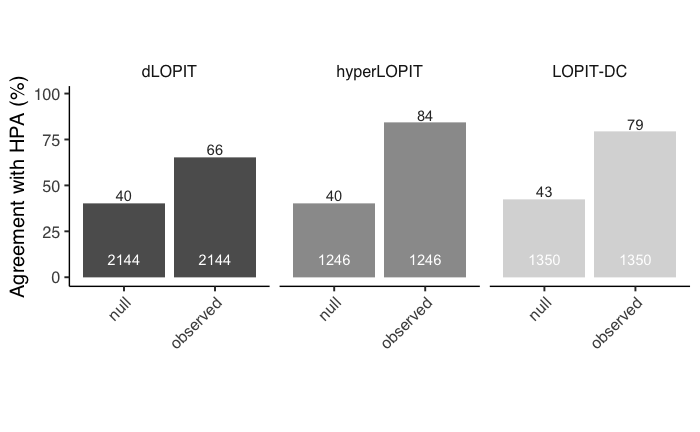

```r
ggsave("../../../../5_manuscript_figures/Figure_1/hpa/barplot_combined.pdf",
       height=4.5, width=8)
```

Plot histogram of raw distributions

```r
observed_means <- plot_data %>%
  filter(hpa == "all", values == "observed") %>%
  select(x_mean = Mean, method = method)
observed_means$method <- as.factor(observed_means$method)
observed_means <- as_tibble(observed_means)
null_dat$method <- as.factor(null_dat$method)
null_dat <- as_tibble(null_dat)

q <-
  null_dat %>%
  filter(hpa == "all") %>%
  ggplot(aes(null*100)) +
  geom_histogram(aes(y = after_stat(density)),
                   fill="grey", colour="white", bins = 80) +
  geom_density() +
  facet_wrap(~method) +
  theme_camprot(border=FALSE, base_family='sans', base_size=15) +
  theme(strip.background=element_blank()) +
        # strip.text = element_text(hjust=1)) +
  xlab('Agreement with HPA (%)') +
  scale_x_continuous(limits = c(10, 90)) +
  geom_vline(data = observed_means, aes(xintercept = x_mean*100),
             color="blue", linewidth = .5) +
  # geom_vline(data=filter(null_dat, method=="dLOPIT"), aes(xintercept=70, colour="pink"))
  geom_text(data = observed_means,
            aes(x = x_mean*100 + 4 , y = .3,
                label = paste0("Observed = ", round(x_mean*100), "%")),
            colour = "blue", check_overlap = TRUE, size = 4, angle = 90)
q

ggsave("../../../../5_manuscript_figures/Figure_1/hpa/density_combined.png",
       height=4, width=9)
```

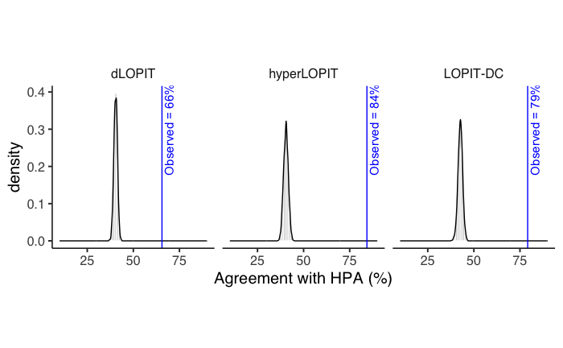

```r
ggsave("../../../../5_manuscript_figures/Figure_1/hpa/density_combined.pdf",
       height=4, width=9)
```

Plot histogram of raw distributions for every LOPIT and every evidence level

```r
observed_means <- plot_data %>%
  filter(hpa != "all", values == "observed") %>%
  select(x_mean = Mean, method = method, hpa = hpa)
observed_means$method <- as.factor(observed_means$method)
observed_means<- as_tibble(observed_means)
null_dat$method <- as.factor(null_dat$method)
null_dat$hpa <- factor(null_dat$hpa,
                       levels = c("all", "Enhanced", "Supported", "Approved"))

q <-
  null_dat %>%
  filter(hpa != "all") %>%
  ggplot(aes(null*100)) +
  geom_histogram(aes(y = after_stat(density)),
                   fill="grey60", colour="white", bins = 50) +
  geom_density(fill = "white", alpha = .6) +
  facet_grid(hpa~method) +
  theme_camprot(border=FALSE, base_family='sans', base_size=15) +
  theme(strip.background=element_blank()) +
        # strip.text = element_text(hjust=1)) +
  xlab('Agreement with HPA (%)') +
  # scale_x_continuous(breaks=seq(0,100,25), expand = c(0,1)) +
  # coord_cartesian(xlim = c(, 100)) +
  geom_vline(data = observed_means, aes(xintercept = x_mean*100, group = hpa),
             color="blue", linewidth = .5) +
  # geom_vline(data=filter(null_dat, method=="dLOPIT"),
  #            aes(xintercept=70, colour="pink")) +
  # #
  geom_text(data = observed_means,
            aes(x = x_mean*100 + 4 , y = .2,
                label = paste0("Observed = ", round(x_mean*100), "%")),
            colour = "blue", check_overlap = TRUE, size = 4, angle = 90) +
  # coord_cartesian(xlim = c(10, 105), ylim = c(0, 0.3)) +
  scale_x_continuous(limits = c(10, 100))
q

ggsave("../../../../5_manuscript_figures/Figure_1/hpa/density_all_levels.png",
       height=8, width=10)
```

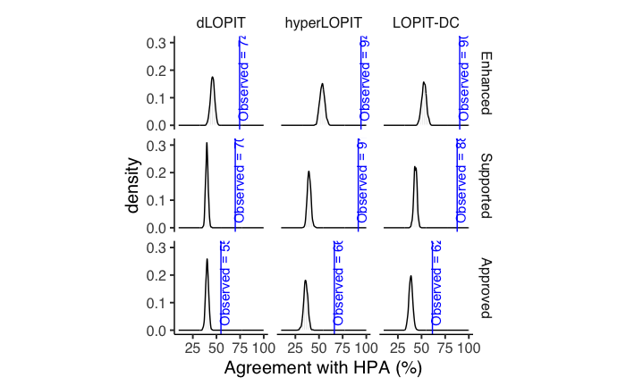

```r
ggsave("../../../../5_manuscript_figures/Figure_1/hpa/density_all_levels.pdf",
       height=8, width=10)
```

Tabulate results

```r
null_dat %>% group_by(method, hpa) %>%
  summarise(mean = mean(null), min = min(null), max = max(null))
```

SI Fig 1 (h) Density plots showing null distributions and the observed values for the agreement between LOPIT classifications and Cell Atlas data from the Human Protein Atlas (HPA). Agreement means the LOPIT classification is within the Cell Atlas annotations. Randomisation tests were performed 1000 times for each HPA level and for each LOPIT dataset. In each case the observed values exceeded the 100th percentile of the null distribution. The observed agreement is marked on the density plots in blue.